# 4-Statistical-Inference

Ethan Rogers

07/31/2026

# Translate research question(s) to statistical hypothesis

We will test two hypotheses:

- **Hypothesis A**, *between-subjects*: Control vs. Osteoarthritis, in Medial tissues
- **Hypothesis B**, *within-subjects*: Lateral vs. Medial, in the Osteoarthritis condition

To test these hypotheses, we must express them in terms of the model parameters. We can use the estimated mean intensity of different sets of tissues and conditions. For both hypotheses, we assume that there is no difference between the mean intensity in each set of tissues and conditions. For example, for Hypothesis A, we expect that the estimate is zero, i.e., $\bar{Y}_{Control, Medial} - \bar{Y}_{Osteoarthritis, Medial} = 0$.

In practice, statistical software will do this translation using the structure of the model, but we must still specify to the software what tests we want it to perform.

# Test hypotheses of interest

Like statistical modeling, we perform statistical testing in Cardinal or externally. Both approaches require specifying a contrast. Formally, a contrast is a linear combination of coefficients for each term in the model that sum to zero. More simply, a contrast is a set of coefficients that, when multiplied in sequence with the model parameter estimates, sums to the estimate of the comparison being tested in the hypothesis that uses all model terms. We generally don’t have to specify them ourselves and can instead use the terms of the model with standard statistical packages.

## Method 1: Comparison testing in Cardinal

`Cardinal::contrastTest()` offers arguments to specify custom contrasts using `emmeans` syntax and performed using `emmeans`. First, we will load the `meansTest` results object from 3-Statistical-Modeling. The results object contains a summary data frame accessible with `mtops()` and the `lmer` models. We will also load the results from manual diagnosis of model fit, creating a list of features that adequately meet model assumptions.

```r
load(file.path("Outputs", "meansTest_cartilage_lmer.RData"))

model_fit_eval <- read_csv(file.path("Outputs", "feature-model-fit-evaluation-utd.csv"), show_col_types = FALSE) |>
  mutate(across(qq:outliers, as.factor))

passed <- model_fit_eval |>
          filter(qq == "ok" &
            var == "ok" &
            outliers == "ok" )
```

### Run tests

In `emmeans`, which Cardinal uses for hypothesis testing and which we will use externally, we specify `~condition * tissue` and supply `"pairwise"` as the `method` to get all pairwise contrasts. `emmeans` offers tremendous functionality and versatility, with [many possible ways to specify contrasts](https://cran.r-project.org/web/packages/emmeans/vignettes/comparisons.html). We will explore other syntax when we repeat these analyses externally from Cardinal in the next part of this workflow.

```r
measTest_models_with_acceptable_fit <- lmer_means_test[passed$fid]

h <- Cardinal::contrastTest(measTest_models_with_acceptable_fit, ~condition * tissue, method="pairwise")
```

Cardinal adds tests to the results object in a wide fashion, with each test having an identifying prefix. That is quite ugly, so below is an example of the `emmeans` object returned for each model, in this case the first feature model for 897.442 m/z.

```r
knitr::kable(h[[1]])
```

| contrast | estimate | SE | df | t.ratio | p.value |
| --- | --- | --- | --- | --- | --- |
| Control Lateral - Osteoarthritis Lateral | 2.402967 | 10.028131 | 7.795903 | 0.2396226 | 0.8168025 |
| Control Lateral - Control Medial | -9.850110 | 5.168622 | 6.000000 | -1.9057515 | 0.1053265 |
| Control Lateral - Osteoarthritis Medial | -10.925533 | 10.028131 | 7.795903 | -1.0894885 | 0.3084664 |
| Osteoarthritis Lateral - Control Medial | -12.253076 | 10.028131 | 7.795903 | -1.2218704 | 0.2574131 |
| Osteoarthritis Lateral - Osteoarthritis Medial | -13.328500 | 5.168622 | 6.000000 | -2.5787336 | 0.0418406 |
| Control Medial - Osteoarthritis Medial | -1.075424 | 10.028131 | 7.795903 | -0.1072407 | 0.9173064 |

Notice there are six tests - every pairwise combination of the 4 (2x2) unique levels of condition and tissue. For our purposes, we only care about the `Control Medial - Osteoarthritis Medial` (hypothesis A) and `Osteoarthritis Lateral - Osteoarthritis Medial` (hypothesis B). Each comparison offers an `estimate`, `t_ratio` (aka t-statistic), and `p_value`. The `estimate` is the effect estimate and `t_ratio` the signal (estimate) to noise (standard error of the estimate) ratio. To get the reverse, say, `Osteoarthritis Medial - Osteoarthritis Lateral`, simply flip the sign of the estimate and t ratio. All else will be the same.

We can see that the p-value is large for 897.442 m/z from Hypothesis A above, indicating that we cannot reject the null hypothesis; any difference in mean abundance between conditions in medial tissues is not statistically significant.

### Correct for multiple testing

Running more tests increases the probability that one of the tests will be a false positive. We can correct for this in a variety of ways, such as globally lowering the threshold for significance (e.g., the Bonferroni correction). The preferred method, however, is to correct the false discovery rate (FDR), or the false-positive rate of just our positive tests. By setting an acceptable rate of positive tests that are false (in our case 0.05 per comparison, or 0.1 overall), we can apply a less strict correction. Cardinal includes a function for FDR correction, `topFeatures`.

```r
kableExtra::kbl(topFeatures(h, n=5, sort.by = 2)) |>
  kableExtra::kable_styling(full_width = FALSE) |>
  kableExtra::scroll_box(width = "100%", height = "200px")
```

| i | mz | singular | Control.Lateral…Osteoarthritis.Lateral.estimate | Control.Lateral…Control.Medial.estimate | Control.Lateral…Osteoarthritis.Medial.estimate | Osteoarthritis.Lateral…Control.Medial.estimate | Osteoarthritis.Lateral…Osteoarthritis.Medial.estimate | Control.Medial…Osteoarthritis.Medial.estimate | Control.Lateral…Osteoarthritis.Lateral.pvalue | Control.Lateral…Control.Medial.pvalue | Control.Lateral…Osteoarthritis.Medial.pvalue | Osteoarthritis.Lateral…Control.Medial.pvalue | Osteoarthritis.Lateral…Osteoarthritis.Medial.pvalue | Control.Medial…Osteoarthritis.Medial.pvalue | Control.Lateral…Osteoarthritis.Lateral.fdr | Control.Lateral…Control.Medial.fdr | Control.Lateral…Osteoarthritis.Medial.fdr | Osteoarthritis.Lateral…Control.Medial.fdr | Osteoarthritis.Lateral…Osteoarthritis.Medial.fdr | Control.Medial…Osteoarthritis.Medial.fdr |
| --- | --- | --- | --- | --- | --- | --- | --- | --- | --- | --- | --- | --- | --- | --- | --- | --- | --- | --- | --- | --- |
| 1 | 897.4416 | FALSE | 2.402967 | -9.8501095 | -10.925533 | -12.25308 | -13.328500 | -1.075424 | 0.8168025 | 0.1053265 | 0.3084664 | 0.2574131 | 0.0418406 | 0.9173064 | 0.9789619 | 0.5854771 | 0.9915765 | 0.9146308 | 0.9980024 | 0.997641 |
| 2 | 1040.4750 | FALSE | 1.255339 | -10.0286449 | -5.925070 | -11.28398 | -7.180408 | 4.103575 | 0.9050097 | 0.0925237 | 0.5771972 | 0.3012208 | 0.2022658 | 0.6978276 | 0.9895490 | 0.5839218 | 0.9915765 | 0.9146308 | 0.9980024 | 0.997641 |
| 3 | 1068.5039 | FALSE | 10.182713 | -0.5757686 | -1.081772 | -10.75848 | -11.264485 | -0.506003 | 0.6179581 | 0.9765728 | 0.9575166 | 0.5984591 | 0.5711580 | 0.9801199 | 0.9789619 | 0.9949520 | 0.9943820 | 0.9906668 | 0.9980024 | 0.997641 |
| 4 | 1110.5592 | FALSE | -23.199050 | 0.6952351 | -9.235509 | 23.89428 | 13.963540 | -9.930745 | 0.4802242 | 0.9822520 | 0.7766997 | 0.4674563 | 0.6578362 | 0.7604502 | 0.9789619 | 0.9949520 | 0.9915765 | 0.9742234 | 0.9980024 | 0.997641 |
| 8 | 1126.5201 | TRUE | -35.713661 | -24.3037167 | -9.041481 | 11.40994 | 26.672179 | 15.262236 | 0.3483084 | 0.5191123 | 0.8090066 | 0.7605205 | 0.4800215 | 0.6839608 | 0.9789619 | 0.8058600 | 0.9915765 | 0.9906668 | 0.9980024 | 0.997641 |

`topFeatures` applies FDR correction to every set of p-values independently. This is important because FDR correction is sensitive to the distribution of p-values. We will explore this later. Now, let’s extract our p-values and see if any are significant.

```r
results_tibble_h1 <- as_tibble(topFeatures(h)) |>
  select(i, mz, starts_with("Control.Medial...Osteoarthritis.Medial.")) |>
  rename_with(~ str_remove(.x, fixed("Control.Medial...Osteoarthritis.Medial.")),
              starts_with("Control.Medial...Osteoarthritis.Medial.")) |>
  arrange(pvalue) |>
  mutate(hypo = "Hypothesis A")


results_tibble_h2 <- as_tibble(topFeatures(h)) |>
  select(i, mz, starts_with("Osteoarthritis.Lateral...Osteoarthritis.Medial.")) |>
  rename_with(~ str_remove(.x, fixed("Osteoarthritis.Lateral...Osteoarthritis.Medial.")),
              starts_with("Osteoarthritis.Lateral...Osteoarthritis.Medial.")) |>
  arrange(pvalue) |>
  mutate(hypo = "Hypothesis B")

knitr::kable(rbind(results_tibble_h1, results_tibble_h2) |>
    mutate(`Significant at 0.1 after FDR adjustment` = fdr < 0.1) |>
    dplyr::summarize(Count = dplyr::n(), .by = c(hypo, `Significant at 0.1 after FDR adjustment`)))
```

| hypo | Significant at 0.1 after FDR adjustment | Count |
| --- | --- | --- |
| Hypothesis A | FALSE | 326 |
| Hypothesis B | FALSE | 326 |

Unfortunately, after adjustment, no findings for either hypothesis are significant. Regardless, let’s make a volcano plot using the unadjusted p-values. We will add a line at unadjusted p = 0.01. (Keep in mind this plot may look different than the one in the accompanying publication, as it uses the estimate rather than the percent difference and may use the flipped comparison. These do not affect the significance. We will show that plot below.)

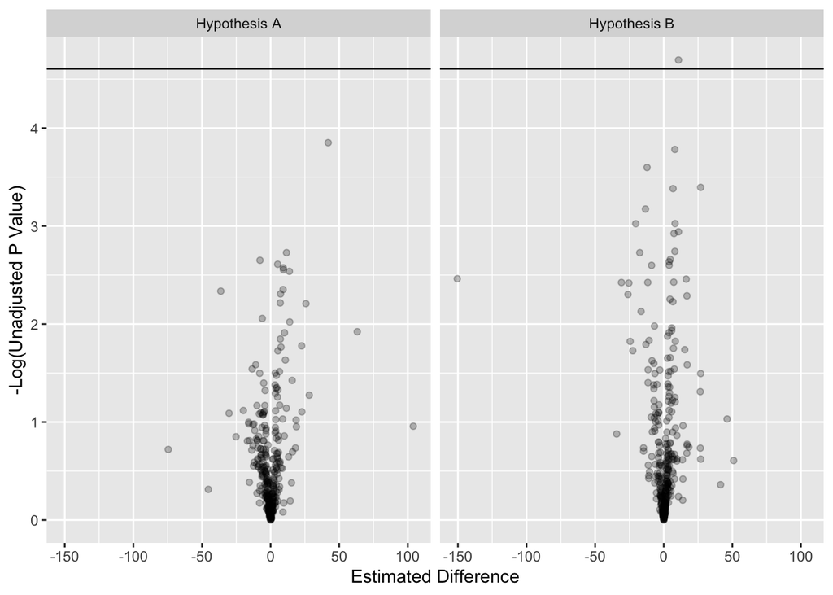

```r
rbind(results_tibble_h1, results_tibble_h2) |>
    ggplot(aes(x = estimate, y = -log(pvalue))) +
    geom_point(alpha = 0.25) +
    facet_wrap("hypo") +
    geom_hline(yintercept = -log(0.01)) +
    xlab("Estimated Difference") +
    ylab("-Log(Unadjusted P Value)")
```

## Method 2: Comparison testing externally

Like in Cardinal, we will test comparisons externally with `emmeans` again, showing multiple ways to specify the same comparison. First, let’s load the models we fit in the last vignette.

```r
load(file.path("Outputs","cartilage_results.RData"))

cartilage_models_OK_fit <- cartilage_res[[1]][passed$fid]
```

We will write a function to perform test hypotheses for each model, but first, let’s experiment with different ways to specify contrasts in `emmeans`, again using the model for 897.442 m/z.

```r
m <- cartilage_models_OK_fit[[1]]
```

### Run tests

We can specify the same pairwise comparison of conditions in tissues from above with the same syntax, but using `emmeans` functions, and selecting only the second contrast for each pair.

```r
#Hypothesis A
emmeans_grid <- emmeans(m, ~ condition | tissue, lmer.df = "satterthwaite")
emmeans::contrast(emmeans_grid, "pairwise", adjust = "none")[2]
```

```
##  contrast                 tissue estimate SE  df t.ratio p.value
##  Control - Osteoarthritis Medial    -1.08 10 7.8  -0.107  0.9173
##
## Degrees-of-freedom method: satterthwaite
```

```r
#Hypothesis B
emmeans_grid <- emmeans(m, ~ tissue | condition, lmer.df = "satterthwaite")
emmeans::contrast(emmeans_grid, "pairwise", adjust = "none")[2]
```

```
##  contrast         condition      estimate   SE df t.ratio p.value
##  Lateral - Medial Osteoarthritis    -13.3 5.17  6  -2.579  0.0418
##
## Degrees-of-freedom method: satterthwaite
```

These function calls use the same default arguments as in `Cardinal::meansTest` - Satterthwaite degrees of freedom calculation and no initial P value adjustment. It also produces the same two contrasts. We can get the same results by passing the `emmeans` object to the pairwise wrapper function, `pairs`:

```r
#Hypothesis A using pairs()
emmeans_grid <- emmeans(m, ~ condition | tissue, lmer.df = "satterthwaite")
pairs(emmeans_grid, adjust = "none")[2]
```

```
##  contrast                 tissue estimate SE  df t.ratio p.value
##  Control - Osteoarthritis Medial    -1.08 10 7.8  -0.107  0.9173
##
## Degrees-of-freedom method: satterthwaite
```

```r
#Hypothesis B using pairs()
emmeans_grid <- emmeans(m, ~ tissue | condition, lmer.df = "satterthwaite")
pairs(emmeans_grid, adjust = "none")[2]
```

```
##  contrast         condition      estimate   SE df t.ratio p.value
##  Lateral - Medial Osteoarthritis    -13.3 5.17  6  -2.579  0.0418
##
## Degrees-of-freedom method: satterthwaite
```

Or, we can directly specify the contrast vector for just the contrasts of interest, using the following specs and methods:

```r
emmeans_grid <- emmeans(m, ~ condition * tissue, lmer.df = "satterthwaite")
contrast(emmeans_grid,
         list(control_vs_osteoarthritis_in_medial = c(0, 0, 1, -1),
         lateral_vs_medial_in_osteoarthritis = c(0, 1, 0, -1)),
         adjust = "none")
```

```
##  contrast                            estimate    SE  df t.ratio p.value
##  control_vs_osteoarthritis_in_medial    -1.08 10.00 7.8  -0.107  0.9173
##  lateral_vs_medial_in_osteoarthritis   -13.33  5.17 6.0  -2.579  0.0418
##
## Degrees-of-freedom method: satterthwaite
```

Now, let’s write a function to test Hypothesis A and B on all models. This function also extracts the mean estimate for the reference so that we can compute the percent change.

```r
signift_cartilage <- bind_rows(lapply(cartilage_models_OK_fit, FUN = function(m){
    emmeans_grid <- emmeans(m, ~ condition * tissue, lmer.df = "satterthwaite")
    k <- contrast(emmeans_grid,
         list(control_vs_osteoarthritis_in_medial = c(0, 0, 1, -1),
         lateral_vs_medial_in_osteoarthritis = c(0, 1, 0, -1)),
         adjust = "none")
    as_tibble(k) |> mutate(reference_estimate = as_tibble(emmeans_grid)  |>
                filter((condition == "Control" & tissue == "Medial" )|
                (condition == "Osteoarthritis" & tissue == "Lateral"))  |>
                arrange(desc(tissue)) |> pull(emmean)) |>
                    mutate(pct_delta = estimate/reference_estimate)
    }), .id = "feature_id") |>
  group_by(contrast) |>
  mutate(p_value_fdr = p.adjust(p.value, method = "fdr")) |>
  ungroup() |>
  mutate(signif_after_fdr_adj = p_value_fdr < 0.1) |>
  arrange(p.value)

save(signift_cartilage, file = file.path("Outputs", "signift_cartilage.RData"))

knitr::kable(head(signift_cartilage))
```

| feature_id | contrast | estimate | SE | df | t.ratio | p.value | reference_estimate | pct_delta | p_value_fdr | signif_after_fdr_adj |
| --- | --- | --- | --- | --- | --- | --- | --- | --- | --- | --- |
| 441 | lateral_vs_medial_in_osteoarthritis | 10.743270 | 2.839817 | 6.000000 | 3.783085 | 0.0091472 | 57.98715 | 0.1852698 | 0.9980024 | FALSE |
| 188 | control_vs_osteoarthritis_in_medial | 41.982287 | 15.854441 | 12.000000 | 2.647983 | 0.0212581 | 137.66637 | 0.3049567 | 0.9976410 | FALSE |
| 391 | lateral_vs_medial_in_osteoarthritis | 8.092353 | 2.661251 | 6.000000 | 3.040808 | 0.0227792 | 68.12273 | 0.1187908 | 0.9980024 | FALSE |
| 27 | lateral_vs_medial_in_osteoarthritis | -12.164462 | 4.196394 | 6.000000 | -2.898789 | 0.0273777 | 37.19640 | -0.3270333 | 0.9980024 | FALSE |
| 179 | lateral_vs_medial_in_osteoarthritis | 26.887812 | 9.798409 | 5.999999 | 2.744100 | 0.0335529 | 95.62985 | 0.2811655 | 0.9980024 | FALSE |
| 426 | lateral_vs_medial_in_osteoarthritis | 6.776685 | 2.477966 | 6.000000 | 2.734778 | 0.0339701 | 59.75542 | 0.1134070 | 0.9980024 | FALSE |

### Correct for multiple testing

As above, we will correct for multiple testing using the FDR method and construct a volcano plot. We have also flipped the comparison to harmonize these results with the accompanying journal article (positive differences mean greater abundance in osteoarthritis conditions or medial tissues).

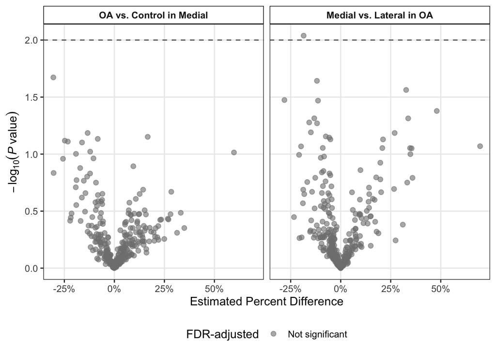

```r
signift_cartilage |>
  ggplot(aes(x = -1 * pct_delta, y = -log10(p.value), color = signif_after_fdr_adj)) +
  geom_point(alpha = 0.6, size = 2) +
  geom_hline(yintercept = -log10(0.01), linetype = "dashed", color = "gray40") +
  facet_wrap(~contrast, labeller = labeller(contrast = c(
    "control_vs_osteoarthritis_in_medial" = "OA vs. Control in Medial",
    "lateral_vs_medial_in_osteoarthritis" = "Medial vs. Lateral in OA"
  ))) +
  scale_x_continuous(labels = scales::percent) +
  scale_color_manual(
    values = c("TRUE" = "#E41A1C", "FALSE" = "gray50"),
    labels = c("TRUE" = "Significant", "FALSE" = "Not significant"),
    name = "FDR-adjusted"
  ) +
  labs(
    x = "Estimated Percent Difference",
    y = expression(-log[10](italic(P)~value))
  ) +
  theme_bw(base_size = 12) +
  theme(
    panel.grid.minor = element_blank(),
    strip.background = element_rect(fill = "white", color = "black"),
    strip.text = element_text(face = "bold"),
    legend.position = "bottom"
  )
```

```r
  ggsave(file.path("Recreated-Figures", "Figure-Statistical-Inference-Volcano.png"), height = 5.75, width = 6, units = "in")
```

## Inspecting the distributions of unadjusted P values for test interdependence

When performing multiple tests, the distribution of p-values can reveal information about the independence of the tests. If the tests are independent, we expect either a uniform distribution (when few tests are significant) or a right-skewed distribution with a peak near zero (when many tests are significant). Deviations from this pattern can indicate that the tests are not independent, which can affect the performance of multiple testing corrections.

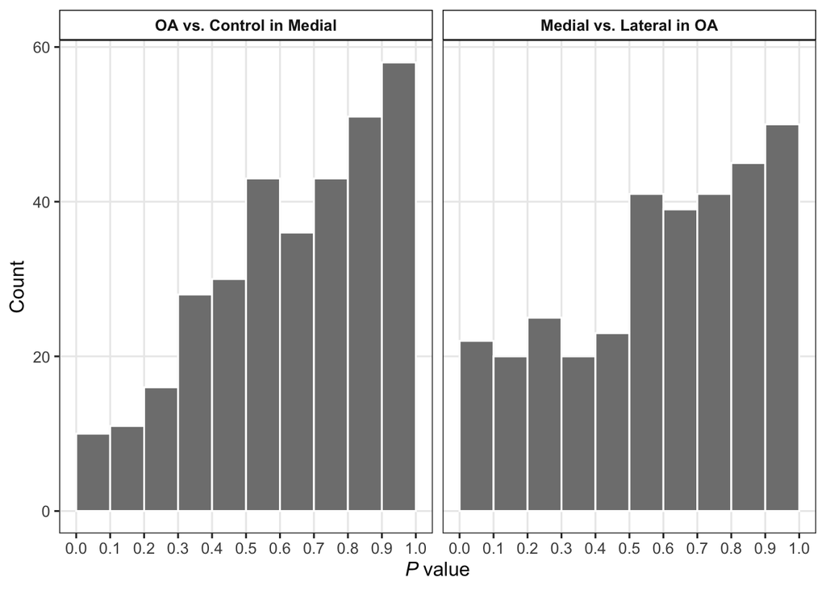

```r
signift_cartilage |>
  ggplot(aes(x = p.value)) +
  geom_histogram(binwidth = 0.1, fill = "gray50", color = "white", boundary = 0) +
  facet_wrap(~contrast, labeller = labeller(contrast = c(
    "control_vs_osteoarthritis_in_medial" = "OA vs. Control in Medial",
    "lateral_vs_medial_in_osteoarthritis" = "Medial vs. Lateral in OA"
  ))) +
  scale_x_continuous(breaks = seq(0, 1, by = 0.1)) +
  labs(
    x = expression(italic(P)~value),
    y = "Count"
  ) +
  theme_bw(base_size = 12) +
  theme(
    panel.grid.minor = element_blank(),
    strip.background = element_rect(fill = "white", color = "black"),
    strip.text = element_text(face = "bold")
  )
```

```r
  ggsave(file.path("Recreated-Figures", "SI-Figure-Statistical-Inference-PValue-Dists.png"), height = 5.75, width = 6, units = "in")
```

As the distribution of p-values is neither uniform nor right-skewed, there may be some interdependence between tests, but this is hard to verify with so few tests overall. It would not be surprising were there interdependence however, as the tests are performed on the same samples and many metabolites are biochemically related. Better clustering of features could eliminate some of this potential interdependence. Some software packages offer methods to account for interdependence in multiple testing correction, such as the `locfdr` package.

This code below will recreate the tables and figures from the manuscript.

```r
knitr::kable(model_fit_eval |> select(-c(fid)))
```

| mz | qq | var | outliers |
| --- | --- | --- | --- |
| 897.4416 | ok | ok | ok |
| 1040.4750 | ok | ok | ok |
| 1068.5039 | ok | ok | ok |
| 1110.5592 | ok | ok | ok |
| 1115.5397 | problem | ok | problem |
| 1118.4718 | problem | ok | ok |
| 1125.5299 | problem | ok | ok |
| 1126.5201 | ok | ok | ok |
| 1128.5170 | ok | ok | ok |
| 1138.5156 | ok | ok | ok |
| 1141.5204 | ok | ok | ok |
| 1156.5223 | ok | ok | ok |
| 1163.4943 | ok | ok | ok |
| 1164.4913 | problem | ok | ok |
| 1171.5321 | ok | problem | ok |
| 1172.5242 | problem | ok | ok |
| 1179.5411 | ok | ok | ok |
| 1180.5354 | ok | ok | ok |
| 1181.5335 | ok | ok | ok |
| 1203.5092 | problem | ok | ok |
| 1204.5446 | problem | ok | ok |
| 1205.5612 | ok | ok | ok |
| 1222.5382 | ok | ok | ok |
| 1233.5655 | problem | ok | problem |
| 1242.5774 | ok | ok | ok |
| 1249.5578 | ok | ok | ok |
| 1257.5776 | ok | ok | ok |
| 1283.5867 | problem | ok | problem |
| 1283.6368 | ok | ok | ok |
| 1285.6011 | ok | ok | ok |

[output cut: 592 more lines]

```r
m <- readMSIData(file.path("Data","Filtering-Aggregation","Preprocessed-NSFiltered-Aggregated-CartilageFiltered50.imzML"))

stopifnot(length(mz(m))==length(model_fit_eval$fid))
stopifnot(length(mz(m))>=max(passed$fid))

signift_cartilage |>
  filter(contrast == "control_vs_osteoarthritis_in_medial") |>
  mutate(feature_id = as.integer(feature_id)) |>
  left_join(passed |>
            mutate(feature_id = as.integer(fid))) |>
  mutate(`M/Z` = round(mz, 3),
          Estimate = round(estimate, 3),
          Std.Error = round(SE, 3),
          `P Value` = round(p.value, 3),
          `FDR Adj. P value` = round(p_value_fdr, 3)) |>
  select(`M/Z`, Estimate, Std.Error, `P Value`, `FDR Adj. P value` ) |>
  arrange(`P Value`) |>
  knitr::kable()
```

| M/Z | Estimate | Std.Error | P Value | FDR Adj. P value |
| --- | --- | --- | --- | --- |
| 1609.718 | 41.982 | 15.854 | 0.021 | 0.998 |
| 1719.765 | 11.586 | 5.570 | 0.065 | 0.998 |
| 1404.616 | -7.731 | 3.875 | 0.071 | 0.998 |
| 1701.759 | 5.176 | 2.640 | 0.074 | 0.998 |
| 2655.209 | 9.234 | 4.759 | 0.076 | 0.998 |
| 2582.196 | 9.304 | 4.822 | 0.078 | 0.998 |
| 1448.647 | 13.698 | 7.138 | 0.079 | 0.998 |
| 1700.773 | 9.091 | 4.925 | 0.095 | 0.998 |
| 1163.494 | -36.302 | 20.141 | 0.097 | 0.998 |
| 2583.192 | 7.239 | 4.055 | 0.100 | 0.998 |
| 1840.822 | 7.029 | 4.009 | 0.109 | 0.998 |
| 2214.989 | 25.763 | 14.922 | 0.110 | 0.998 |
| 1933.850 | -6.036 | 3.528 | 0.128 | 0.998 |
| 1719.834 | 13.937 | 8.452 | 0.132 | 0.998 |
| 1426.662 | 63.189 | 40.685 | 0.146 | 0.998 |
| 1738.758 | 10.104 | 6.533 | 0.148 | 0.998 |
| 2011.942 | 7.110 | 4.575 | 0.158 | 0.998 |
| 1697.816 | 22.673 | 15.381 | 0.169 | 0.998 |
| 2325.025 | 7.581 | 5.209 | 0.171 | 0.998 |
| 2169.935 | 5.337 | 3.728 | 0.178 | 0.998 |
| 2348.062 | 10.745 | 7.836 | 0.195 | 0.998 |
| 1531.689 | -10.815 | 7.867 | 0.205 | 0.998 |
| 2268.002 | -13.449 | 10.108 | 0.214 | 0.998 |
| 2324.127 | 6.513 | 5.031 | 0.220 | 0.998 |
| 2014.845 | 3.378 | 2.627 | 0.223 | 0.998 |
| 1729.752 | -7.927 | 6.036 | 0.224 | 0.998 |
| 2101.943 | 4.250 | 3.349 | 0.228 | 0.998 |
| 1410.657 | 15.715 | 12.516 | 0.240 | 0.998 |
| 1512.682 | -5.004 | 4.113 | 0.247 | 0.998 |
| 1583.703 | 3.251 | 2.701 | 0.252 | 0.998 |

[output cut: 296 more lines]

```r
signift_cartilage |>
  filter(contrast == "lateral_vs_medial_in_osteoarthritis") |>
  mutate(feature_id = as.integer(feature_id)) |>
  left_join(passed |>
            mutate(feature_id = as.integer(fid))) |>
  mutate(`M/Z` = round(mz, 3),
          Estimate = round(estimate, 3),
          Std.Error = round(SE, 3),
          `P Value` = round(p.value, 3),
          `FDR Adj. P value` = round(p_value_fdr, 3)) |>
  select(`M/Z`, Estimate, Std.Error, `P Value`, `FDR Adj. P value`) |>
  arrange(`P Value`) |>
  knitr::kable()
```

| M/Z | Estimate | Std.Error | P Value | FDR Adj. P value |
| --- | --- | --- | --- | --- |
| 2044.889 | 10.743 | 2.840 | 0.009 | 0.998 |
| 1969.852 | 8.092 | 2.661 | 0.023 | 0.998 |
| 1257.578 | -12.164 | 4.196 | 0.027 | 0.998 |
| 1596.669 | 26.888 | 9.798 | 0.034 | 0.998 |
| 2014.845 | 6.777 | 2.478 | 0.034 | 0.998 |
| 897.442 | -13.328 | 5.169 | 0.042 | 0.998 |
| 2142.943 | 8.250 | 3.342 | 0.049 | 0.998 |
| 1410.657 | -20.429 | 8.279 | 0.049 | 0.998 |
| 1888.831 | 10.745 | 5.001 | 0.053 | 0.998 |
| 2083.903 | 7.462 | 3.116 | 0.054 | 0.998 |
| 2043.890 | 8.115 | 3.589 | 0.064 | 0.998 |
| 1399.638 | -17.480 | 7.763 | 0.065 | 0.998 |
| 1723.750 | 4.738 | 2.382 | 0.070 | 0.998 |
| 1954.860 | 3.956 | 1.811 | 0.072 | 0.998 |
| 1967.873 | 3.943 | 1.827 | 0.074 | 0.998 |
| 1422.639 | -8.875 | 4.540 | 0.074 | 0.998 |
| 1483.719 | -150.479 | 73.103 | 0.085 | 0.998 |
| 1597.674 | 16.358 | 7.957 | 0.086 | 0.998 |
| 1894.835 | 7.264 | 3.573 | 0.088 | 0.998 |
| 1719.834 | -11.643 | 5.731 | 0.088 | 0.998 |
| 1438.678 | -30.832 | 15.181 | 0.089 | 0.998 |
| 1697.816 | -25.435 | 12.548 | 0.089 | 0.998 |
| 1482.682 | -26.074 | 14.633 | 0.100 | 0.998 |
| 1887.832 | 16.880 | 9.518 | 0.102 | 0.998 |
| 2084.919 | 4.576 | 2.398 | 0.105 | 0.998 |
| 1979.892 | 6.689 | 3.539 | 0.108 | 0.998 |
| 1830.857 | -16.521 | 9.090 | 0.119 | 0.998 |
| 1719.765 | -6.741 | 3.943 | 0.138 | 0.998 |
| 1533.672 | 5.866 | 3.459 | 0.141 | 0.998 |
| 1598.688 | 5.782 | 3.450 | 0.145 | 0.998 |

[output cut: 296 more lines]